# Milestone 2

Paweł Morgen, Zuzanna Mróz, Aleksander Podsiad

# 1 Zabawa zmiennymi

```r
new_columns <- colnames(data_enhanced)[!(colnames(data_enhanced)) %in% colnames(data_preprocessed)]
print(new_columns)
```

```
## [1] "gender"             "retirement_age"     "age_category"
## [4] "never_married"      "employed"           "duration_years"
## [7] "duration_years_cat"
```

Zostały wprowadzone nowe zmienne, utworzone na podstawie starych. Są to:

- `gender` - kobieta/mężyczyzna, na podstawie personal; podział typu singiel/singielka rozbity na prostsze rozróżnienie k/m
- `retirement_age` - True/False, na podstawie age; tutaj uznaliśmy >=65 za wiek emerytalny
- `age_category` - young/middle-aged/old, na podstawie age; przedziały <=39/40-59/>=60
- `never_married` - True/False, na podstaiwe personal; jako że te kategorie nie były najlepsze, np. dla kobiet jedyne kategorie to singielka/[mężata/rozwiedziona/wdowa] podzieliliśmy ludzi na tych którzy nigdy nie byli w związku i na tych co kiedyś byli albo nadal są
- `employed` - True/False, na podstawie present_employement; nie bierzemy uwagi na to ile lat ktoś ma pracę tylko czy faktycznie ma pracę
- `duration_years` - numeryczne, na podstawie duration; jako że duration było w miesiącach przekonwertowaliśmy je na lata
- `duration_years_cat` - <1/1/1<&<2/2/2<&<3/3/3>, na podstawie duration_years; podzielone na pełne lata i pomiędzy przy uznaniu że 3+ lata to już jedna kategoria

# 2 Wstępne modelowanie - drzewo decyzyjne

## 2.1 Audyt modelu

Na początku stworzymy trzy klasyfikatory za pomocą modelu `CART`, kierując się kryteriami:

- w pierwszym przypadku ograniczymy głębokość drzewa i wyznaczymy minimalne rozbicie danych;
- w drugim drzewie zbadamy wpływ parametru `cp` na postać drzewa;
- trzecie drzewo tworzymy domyślną metodą;

Używamy do tego pakietu `mlr`.

```r
task <- makeClassifTask(id = "german_credit", data = data_enhanced, target = "customer_type")
tree1_learner <- makeLearner('classif.rpart',
                             par.vals = list(maxdepth = 2,
                                             minsplit = 5),
                             predict.type = 'prob')
tree2_learner <- makeLearner('classif.rpart',
                             par.vals = list(cp = 0.05),
                             predict.type = 'prob')
tree3_learner <- makeLearner('classif.rpart',
                             predict.type = 'prob')

# Sprawdźmy, czy nasz model będzie sprawiał problemy

cv <- makeResampleDesc("CV", iters = 7)
r1 <- resample(tree1_learner, task, cv, measures = list(auc, acc, ppv), models = TRUE)
r2 <- resample(tree2_learner, task, cv, measures = list(auc, acc, ppv), models = TRUE)
r3 <- resample(tree3_learner, task, cv, measures = list(auc, acc, ppv), models = TRUE)

print(r1$aggr, r2$aggr, r3$aggr)
```

[output not shown]

## 2.2 Trening i ocena skuteczności

Trenujemy drzewa decyzyjne na odpowiednich klasyfikatorach.

```r
tree1 <- train(tree1_learner, task)
tree2 <- train(tree2_learner, task)
tree3 <- train(tree3_learner, task)

# sprawdźmy:
predict(tree1, newdata = data_enhanced) %>%
  performance(measures = list(auc, acc, ppv)) %>%
  print()
```

```
##       auc       acc       ppv
## 0.7213857 0.7310000 0.5654008
```

```r
predict(tree2, newdata = data_enhanced) %>%
  performance(measures = list(auc, acc, ppv)) %>%
  print()
```

```
##       auc       acc       ppv
## 0.7309048 0.7480000 0.6224490
```

```r
predict(tree3, newdata = data_enhanced) %>%
  performance(measures = list(auc, acc, ppv)) %>%
  print()
```

```
##       auc       acc       ppv
## 0.7805095 0.7970000 0.6995885
```

## 2.3 Wizualizacja

Pierwsze drzewo decyzyjne jest dosyć proste ze względu na nałożone ograniczenia.

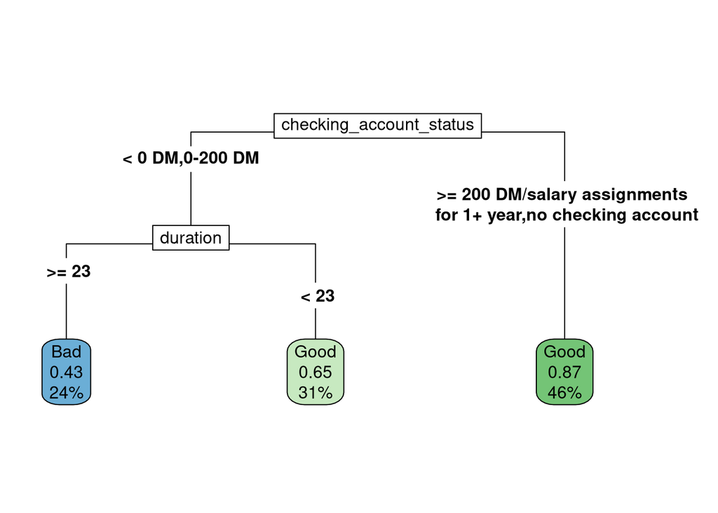

```r
rpart.plot(getLearnerModel(tree1), type = 5, roundint = FALSE)
```

Drugie drzewo ma już trzy poziomy, z czego pierwsze dwa są takie same jak w powyższym.

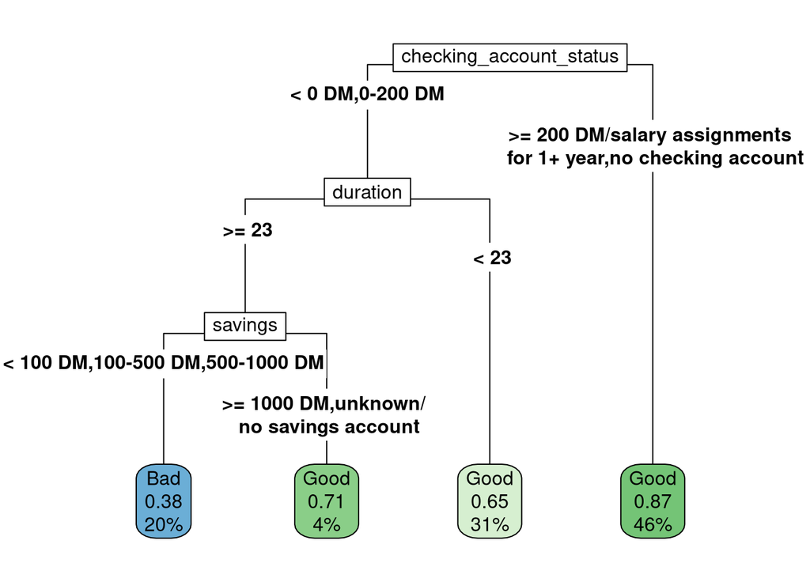

```r
rpart.plot(getLearnerModel(tree2), type = 5, roundint = FALSE)
```

Jeśli klasyfikator pozostawimy z domyślnymi parametrami, tworzy on już bardziej rozbudowane drzewo.

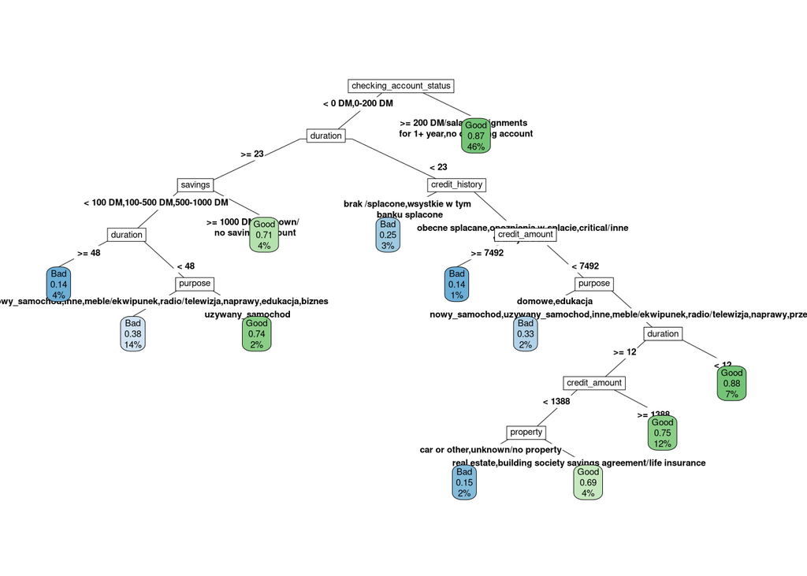

```r
rpart.plot(getLearnerModel(tree3), type = 5, tweak = 1.7, fallen.leaves = FALSE, roundint = FALSE)
```

## 2.4 Omówienie

Okazuje się, że wszystkie trzy drzewa jako jedne z ważniejszych zmiennych wyznaczają `checking_account_status` oraz `duration`. Zmienne te umożliwiają drzewom tzw. optymalny podział dla najskuteczniejszej predykcji. Pierwsze dwa poziomy są wszędzie takie same, a kolejne drzewa są rozszerzeniami poprzednich. Z oczywistych względów ostatnie drzewo ma największą skuteczność przewidywania, lecz co ciekawe nie jest ona o wiele większa nawet od dwu poziomowego drzewa (różnica accuracy to około 6%). Na testowane drzewa decyzyjne nakładaliśmy te ograniczenia ze względu na podatność do overfittingu tego modelu.

# 3 Częściowe wyjaśnienie - ważność zmiennych

Wybiegnijmy trochę w przyszłość i zobaczmy, co o ważności zmiennych myślą modele `ranger` (las losowy) oraz `gbm`.

```r
learner_ranger <- makeLearner("classif.ranger", par.vals = list(mtry = 3), predict.type = "prob")
learner_gbm <- makeLearner('classif.gbm',predict.type = 'prob')

# Audyt
cv <- makeResampleDesc("CV", iters = 7)
r1 <- resample(learner_ranger, task, cv, measures = list(auc, acc, ppv), models = TRUE)

r2 <- resample(learner_gbm, task, cv, measures = list(auc, acc, ppv), models = TRUE)
```

[output not shown]

```r
# ranger CV performance:
print(r1$aggr)
```

```
## auc.test.mean acc.test.mean ppv.test.mean
##     0.7916138     0.7699765     0.7260128
```

```r
# gbm CV performance:
print(r2$aggr)
```

```
## auc.test.mean acc.test.mean ppv.test.mean
##     0.7862321     0.7529724     0.6489823
```

```r
generateFeatureImportanceData(task, learner = learner_ranger, nmc = 10) -> feat_ranger
generateFeatureImportanceData(task, learner = learner_gbm, nmc = 30) -> feat_gbm
```

```
## Distribution not specified, assuming bernoulli ...
```

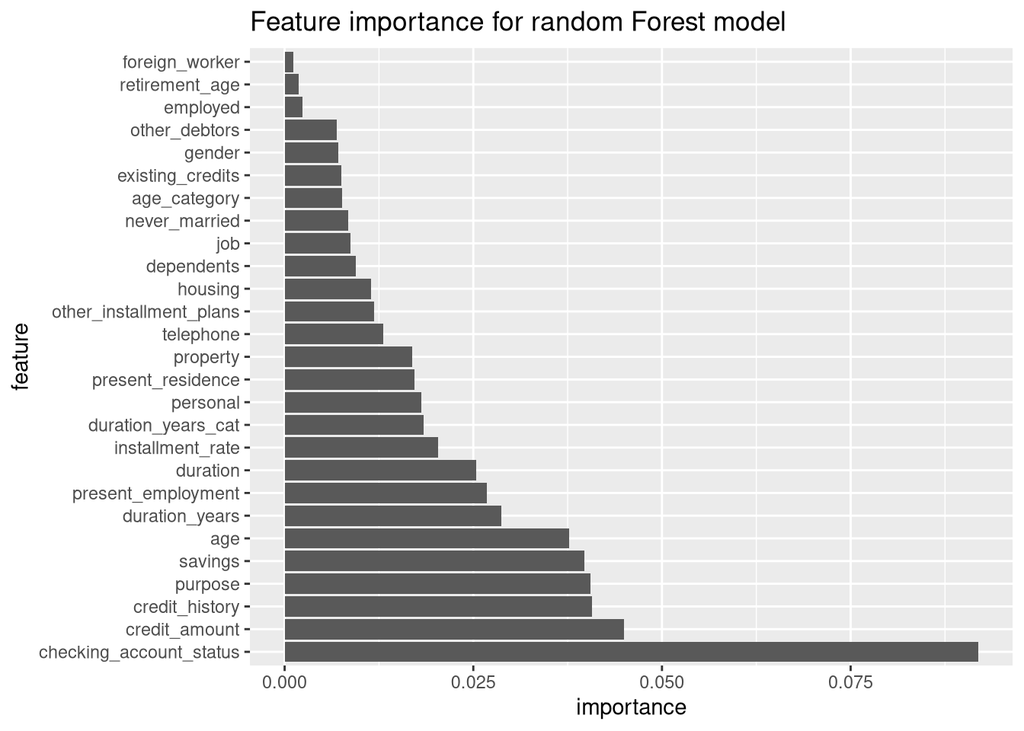

```r
plot_importance <- function(feat){
data.frame(importance = as.numeric(t(as.matrix(feat$res))),
           feature = colnames(feat$res)) %>%
  arrange(desc(importance)) %>%
  mutate(feature = factor(feature, levels = feature))-> feats_summarized
ggplot(feats_summarized, aes(x = feature, y = importance)) + geom_col() + coord_flip()}

plot_importance(feat_ranger) + labs(title = 'Feature importance for random Forest model')
```

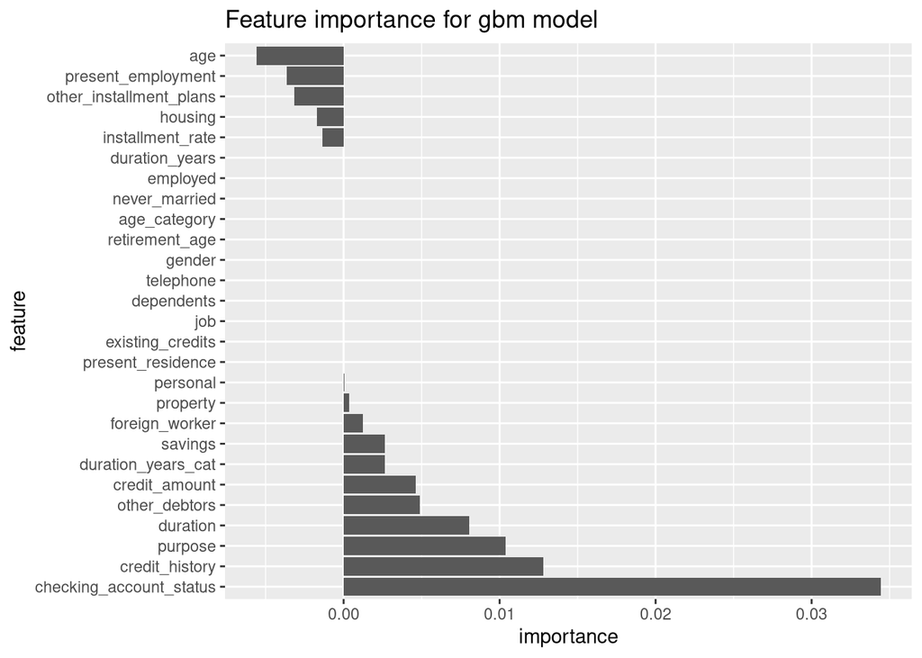

```r
plot_importance(feat_gbm) + labs(title = 'Feature importance for gbm model')
```

Jak widzimy, bardziej skomplikowane modele podzielają zdanie drzewa decyzyjnego o ogromnym znaczeniu zmiennej `checking_account_status`. Zmienne `duration` oraz `savings` również się pojawiają jako istotne. Zmienne `credit_amount` oraz `credit_history`, wykorzystywane w skomplikowanym drzewie nr 3, należą do najistotniejszych.

Pominięcie innych zmiennych uznanych za istotne możemy uznać za poświęcenie w imię prostoty zbudowanego modelu.

# 4 Porównanie z bardziej skomplikowanymi modelami

```r
ranger_model <- train(learner_ranger, task)
gbm_model <- train(learner_gbm, task)
```

```
## Distribution not specified, assuming bernoulli ...
```

```r
predictions <- predict(tree2, newdata = data3)
troublesome_data <- data3[predictions$data$truth != predictions$data$response,]
gbm_predicitons <- predict(gbm_model, newdata = data3)
ranger_predicitons <- predict(ranger_model, newdata = data3)
tree_predictions <- predict(tree2, newdata = data3)

troublesome_gbm_predicitons <- predict(gbm_model, newdata = troublesome_data)
troublesome_ranger_predicitons <- predict(ranger_model, newdata = troublesome_data)
troublesome_tree_predictions <- predict(tree2, newdata = troublesome_data)



# kalkulacja strat

buisness_summary <- function(predictions){
  select(data3, credit_amount, customer_type) %>%
    mutate(customer_type_predicted = predictions,
          false_positives = if_else(customer_type == 'Bad' & customer_type_predicted == 'Good',
                                credit_amount, 0),
          false_negatives = if_else(customer_type == 'Good' & customer_type_predicted == 'Bad',
                                   credit_amount, 0),
          true_positives = if_else(customer_type == 'Good' & customer_type_predicted == 'Good',
                                    credit_amount, 0),
          true_negatives = if_else(customer_type == 'Bad' & customer_type_predicted == 'Bad',
                                   credit_amount, 0)) %>%
    summarise(total_lost_credit = sum(false_positives),
              total_lost_potential = sum(false_negatives),
              total_correct_credit = sum(true_positives),
              total_correct_decline = sum(true_negatives))
}
predictions_list <- list(tree_predictions,
                         gbm_predicitons,
                         ranger_predicitons)
summary <- bind_rows(lapply(predictions_list, function(v) buisness_summary(v$data$response))) %>%
  mutate(model = c('rpart', 'gbm', 'ranger'),
         accuracy_overall = sapply(predictions_list, function(p) performance(p, measures = acc)),
         accuracy_for_troublesome = c(0,
                                      performance(troublesome_gbm_predicitons, acc),
                                      performance(troublesome_ranger_predicitons, acc)))
knitr::kable(summary)
```

| total_lost_credit | total_lost_potential | total_correct_credit | total_correct_decline | model | accuracy_overall | accuracy_for_troublesome |
| --- | --- | --- | --- | --- | --- | --- |
| 526771 | 346330 | 1743490 | 654667 | rpart | 0.748 | 0.0000000 |
| 512058 | 269341 | 1820479 | 669380 | gbm | 0.790 | 0.4087302 |
| 113521 | 12264 | 2077556 | 1067917 | ranger | 0.954 | 0.8253968 |

# 5 Podsumowanie

Prosty model drzewa decyzyjnego okazuje się niewiele słabszy od modelu `gbm`, zachowując przy tym czytelność i przejrzystość. Oczywiście, jest słabszy od modelu lasu losowego, ale tego się spodziewaliśmy - uproszczenie modelu pociąga za sobą gorszą skuteczność.

Co ciekawe, więcej zmiennych niekoniecznie znaczy lepiej dla modelu - jeśli te zmienne są skorelowane z już istniejącymi, nie niosą ze sobą nowej infromacji i model nie uznaje ich za istotne.